# capstoneProject_NEWS

### Mount Google Drive

First, we need to mount Google Drive to access the CSV files.

```python
from google.colab import drive
drive.mount('/content/drive')
```

### Imports and Data Loading

Import necessary libraries, define helper functions, and load the dataset into a pandas DataFrame.

```python
import re
from pathlib import Path
from collections import Counter

import numpy as np
import pandas as pd
from sklearn.decomposition import TruncatedSVD
from sklearn.feature_extraction.text import TfidfVectorizer, CountVectorizer
from sklearn.feature_extraction import text as sklearn_text
import matplotlib.pyplot as plt
import seaborn as sns # Added for enhanced plotting
import os

# Base path to data CSV files in Google Drive
base_path = '/content/drive/MyDrive/ColabNotebooks/CapstoneProject/dataset/'

CSV_FILES = [
    'business_data.csv',
    'education_data.csv',
    'entertainment_data.csv',
    'sports_data.csv',
    'technology_data.csv',
]

def print_section(title):
    print('\n' + '=' * 80)
    print(title)
    print('=' * 80 + '\n')

def load_data(files):
    frames = []
    for path in files:
        df = pd.read_csv(base_path+path)
        df['source_file'] = path
        frames.append(df)
    return pd.concat(frames, ignore_index=True)

df = load_data(CSV_FILES)
```

## 1. Data Report

- Understanding the data
- Check the number of rows and columns in each dataset
- Assess the completeness and structure of the columns (headlines, description, content, URL, category)
- Ensure clarity on what each column represents
- Rename variables if necessary for improved readability

```python
def data_report(df_to_report):
    print_section('Data Report')
    print('Total rows:', len(df_to_report))
    print('Total columns:', len(df_to_report.columns))
    print('Columns:', df_to_report.columns.tolist())
    print('\nColumn types:')
    print(df_to_report.dtypes)
    print('\nMissing values by column:')
    print(df_to_report.isna().sum())

    # Exclude columns with list dtypes from duplicated check
    # Assuming 'tokens' is the only column that contains lists and causes issues
    # If there are other list columns, they should also be excluded
    df_for_duplicate_check = df_to_report.drop(columns=['tokens'], errors='ignore')
    print('\nNumber of duplicate rows (excluding list columns):', df_for_duplicate_check.duplicated().sum())

    print('\nCategory distribution:')
    print(df_to_report['category'].value_counts())
    print('\nSample rows:')
    display(df_to_report.head(3))

data_report(df)
```

```
================================================================================
Data Report
================================================================================

Total rows: 10000
Total columns: 6
Columns: ['headlines', 'description', 'content', 'url', 'category', 'source_file']

Column types:
headlines      object
description    object
content        object
url            object
category       object
source_file    object
dtype: object

Missing values by column:
headlines      0
description    0
content        0
url            0
category       0
source_file    0
dtype: int64

Number of duplicate rows (excluding list columns): 0

Category distribution:
category
business         2000
education        2000
entertainment    2000
sports           2000
technology       2000
Name: count, dtype: int64

Sample rows:
```

|  | headlines | description | content | url | category | source_file |
| --- | --- | --- | --- | --- | --- | --- |
| 0 | Nirmala Sitharaman to equal Morarji Desai’s re... | With the presentation of the interim budget on... | Sitharaman, the first full-time woman finance ... | https://indianexpress.com/article/business/bud... | business | business_data.csv |
| 1 | ‘Will densify network, want to be at least no.... | 'In terms of market share, we aim to double it... | The merger of Tata group’s budget airlines Air... | https://indianexpress.com/article/business/avi... | business | business_data.csv |
| 2 | Air India group to induct an aircraft every si... | Air India currently has 117 operational aircra... | The Air India group plans to induct one aircra... | https://indianexpress.com/article/business/avi... | business | business_data.csv |

## 2. Initial Exploratory Data Analysis

- Analyze word counts or character lengths for the headlines, description, and content
- Determine the distribution of articles in each category (e.g., Sports, Technology)
- Create word clouds or frequency plots to show the most common words used in each category
- Investigate the length of headlines, description, and content across different categories to spot patterns (e.g., longer articles in one category)

```python
print_section('Initial Exploratory Data Analysis')

print('Headline length stats:')
print(df['headline_word_count'].describe())
print('\nDescription length stats:')
print(df['description_word_count'].describe())
print('\nContent length stats:')
print(df['content_word_count'].describe())
```

```
================================================================================
Initial Exploratory Data Analysis
================================================================================

Headline length stats:
count    10000.000000
mean        13.897300
std          4.402487
min          4.000000
25%         11.000000
50%         13.000000
75%         16.000000
max         33.000000
Name: headline_word_count, dtype: float64

Description length stats:
count    10000.000000
mean        26.388800
std          8.544585
min          3.000000
25%         20.000000
50%         25.000000
75%         32.000000
max         71.000000
Name: description_word_count, dtype: float64

Content length stats:
count    10000.000000
mean       224.366300
std        209.777919
min         15.000000
25%        102.000000
50%        144.000000
75%        261.000000
max       2863.000000
Name: content_word_count, dtype: float64
```

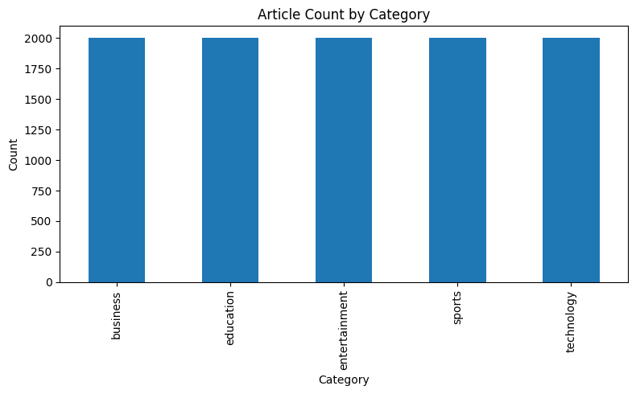

```python
def plot_category_distribution(df_to_plot):
    counts = df_to_plot['category'].value_counts().sort_values(ascending=False)
    fig, ax = plt.subplots(figsize=(8, 5))
    counts.plot(kind='bar', color='tab:blue', ax=ax)
    ax.set_title('Article Count by Category')
    ax.set_xlabel('Category')
    ax.set_ylabel('Count')
    plt.tight_layout()
    plt.show()
    plt.close(fig)

plot_category_distribution(df)
```

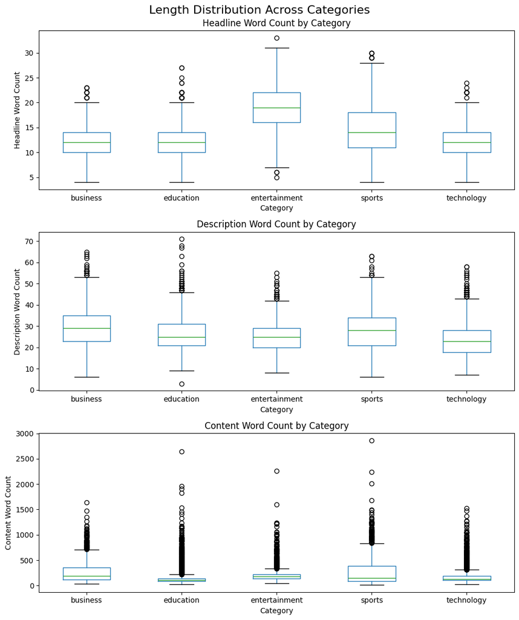

```python
def plot_length_distributions(df_to_plot):
    fig, axes = plt.subplots(3, 1, figsize=(10, 12), constrained_layout=True)
    df_to_plot.boxplot(column=['headline_word_count'], by='category', ax=axes[0], grid=False)
    axes[0].set_title('Headline Word Count by Category')
    axes[0].set_xlabel('Category')
    axes[0].set_ylabel('Headline Word Count')
    df_to_plot.boxplot(column=['description_word_count'], by='category', ax=axes[1], grid=False)
    axes[1].set_title('Description Word Count by Category')
    axes[1].set_xlabel('Category')
    axes[1].set_ylabel('Description Word Count')
    df_to_plot.boxplot(column=['content_word_count'], by='category', ax=axes[2], grid=False)
    axes[2].set_title('Content Word Count by Category')
    axes[2].set_xlabel('Category')
    axes[2].set_ylabel('Content Word Count')
    fig.suptitle('Length Distribution Across Categories', fontsize=16)
    plt.tight_layout()
    plt.show()
    plt.close(fig)

plot_length_distributions(df)
```

## 3. Data Pre-processing

- Remove stopwords (common words like "and," "the" which don’t contribute to meaning)
- Handle punctuation, special characters, numbers, and other non-alphabetic symbols
- Perform case normalization (convert text to lowercase)
- Handle missing values in the description or content fields. This could include dropping rows or filling missing values with a placeholder
- Identify and handle articles with unusually short or long content (e.g., less than 5 words could be an outlier)
- Transform text data into numerical format using vectorization techniques (e.g., TF-IDF, Bag of Words, or word embeddings)

### Select VECTORIZATION_METHOD

#### options: 'bow', 'tfidf', 'embeddings'

```python
VECTORIZATION_METHOD = 'embeddings'  # options: 'bow', 'tfidf', 'embeddings'
```

```python
STOP_WORDS = sklearn_text.ENGLISH_STOP_WORDS
DROP_OUTLIERS = True
MIN_CONTENT_WORDS = 5
MAX_CONTENT_WORDS = 5000
MAX_FEATURES = 10000
EMBEDDING_SIZE = 100

def normalize_text(text, remove_stopwords=True):
    if pd.isna(text):
        return ''
    text = str(text)
    text = re.sub(r'http\S+|www\S+', ' ', text)
    text = re.sub(r'<[^>]+>', ' ', text)
    text = re.sub(r'[^a-zA-Z\s]', ' ', text)
    text = text.lower()
    tokens = text.split()
    if remove_stopwords:
        tokens = [token for token in tokens if token not in STOP_WORDS and len(token) > 1]
    else:
        tokens = [token for token in tokens if len(token) > 1]
    return ' '.join(tokens)

def compute_length_features(df_to_process):
    df_to_process['headline_length'] = df_to_process['headlines'].fillna('').astype(str).apply(len)
    df_to_process['headline_word_count'] = df_to_process['headlines'].fillna('').astype(str).apply(lambda s: len(s.split()))
    df_to_process['description_length'] = df_to_process['description'].fillna('').astype(str).apply(len)
    df_to_process['description_word_count'] = df_to_process['description'].fillna('').astype(str).apply(lambda s: len(s.split()))
    df_to_process['content_length'] = df_to_process['content'].fillna('').astype(str).apply(len)
    df_to_process['content_word_count'] = df_to_process['content'].fillna('').astype(str).apply(lambda s: len(s.split()))
    return df_to_process

def preprocess_dataframe(df_to_process):
    df_to_process = df_to_process.copy()
    for column in ['headlines', 'description', 'content']:
        df_to_process[column] = df_to_process[column].fillna('').astype(str)
    df_to_process['category'] = df_to_process['category'].astype(str).str.strip().str.lower()

    df_to_process = compute_length_features(df_to_process)
    df_to_process['is_short_content'] = df_to_process['content_word_count'] < MIN_CONTENT_WORDS
    df_to_process['is_long_content'] = df_to_process['content_word_count'] > MAX_CONTENT_WORDS
    df_to_process['content_outlier'] = df_to_process['is_short_content'] | df_to_process['is_long_content']

    if DROP_OUTLIERS:
        before = len(df_to_process)
        df_to_process = df_to_process[~df_to_process['content_outlier']].copy()
        print(f'Dropped {before - len(df_to_process)} outlier rows based on content length.')

    df_to_process['headlines_clean'] = df_to_process['headlines'].apply(lambda x: normalize_text(x, remove_stopwords=True))
    df_to_process['description_clean'] = df_to_process['description'].apply(lambda x: normalize_text(x, remove_stopwords=True))
    df_to_process['content_clean'] = df_to_process['content'].apply(lambda x: normalize_text(x, remove_stopwords=True))
    df_to_process['text'] = (
        df_to_process['headlines_clean'] + ' ' +
        df_to_process['description_clean'] + ' ' +
        df_to_process['content_clean']
    ).str.strip()
    df_to_process['tokens'] = df_to_process['text'].apply(lambda x: x.split())
    return df_to_process # Corrected: return df_to_process instead of df

def build_vectorizer(df_to_vectorize):
    if VECTORIZATION_METHOD == 'bow':
        vectorizer = CountVectorizer(
            strip_accents='unicode',
            stop_words='english',
            max_features=MAX_FEATURES,
            ngram_range=(1, 2),
        )
        X = vectorizer.fit_transform(df_to_vectorize['text'])
        print('BoW matrix shape:', X.shape)
        print('Sample BoW feature names:', vectorizer.get_feature_names_out()[:20])
        return X, vectorizer

    if VECTORIZATION_METHOD == 'tfidf':
        vectorizer = TfidfVectorizer(
            strip_accents='unicode',
            stop_words='english',
            max_features=MAX_FEATURES,
            ngram_range=(1, 2),
        )
        X = vectorizer.fit_transform(df_to_vectorize['text'])
        print('TF-IDF matrix shape:', X.shape)
        print('Sample TF-IDF feature names:', vectorizer.get_feature_names_out()[:20])
        return X, vectorizer

    if VECTORIZATION_METHOD == 'embeddings':
        embedding_vectorizer = TfidfVectorizer(
            strip_accents='unicode',
            stop_words='english',
            max_features=MAX_FEATURES,
            ngram_range=(1, 2),
        )
        X_sparse = embedding_vectorizer.fit_transform(df_to_vectorize['text'])
        n_components = min(EMBEDDING_SIZE, X_sparse.shape[1] - 1)
        svd = TruncatedSVD(n_components=n_components, random_state=42)
        X = svd.fit_transform(X_sparse)
        print('Embedding matrix shape:', X.shape)
        np.save('article_embeddings.npy', X)
        return X, {'vectorizer': embedding_vectorizer, 'svd': svd}

    raise ValueError(f'Unsupported vectorization method: {VECTORIZATION_METHOD}')

# --- Execution of Data Pre-processing steps ---
print_section('Data Pre-processing Execution')

df = preprocess_dataframe(df) # Update the global df with preprocessed data

print('Cleaned text sample:')
display(df[['headlines_clean', 'description_clean', 'content_clean', 'text']].head(2).to_dict(orient='records'))

merged_out = 'merged_preprocessed_data.csv'
df.to_csv(merged_out, index=False)
print('Saved merged preprocessed dataset to', merged_out)

print('Using vectorization method:', VECTORIZATION_METHOD)
X, vectorizer = build_vectorizer(df)
print_section('Text Vectorization Completed')
```

```
================================================================================
Data Pre-processing Execution
================================================================================

Dropped 0 outlier rows based on content length.
Cleaned text sample:
```

```
[{'headlines_clean': 'nirmala sitharaman equal morarji desai record sixth straight budget',
  'description_clean': 'presentation interim budget february nirmala sitharaman surpass records predecessors like manmohan singh arun jaitley chidambaram yashwant sinha presented budgets row',
  'content_clean': 'sitharaman time woman finance minister country presented budgets july present interim vote account budget week presentation interim budget february sitharaman surpass records predecessors like manmohan singh arun jaitley chidambaram yashwant sinha presented budgets row desai fina…
  'text': 'nirmala sitharaman equal morarji desai record sixth straight budget presentation interim budget february nirmala sitharaman surpass records predecessors like manmohan singh arun jaitley chidambaram yashwant sinha presented budgets row sitharaman time woman finance minister country present…
 {'headlines_clean': 'densify network want city pair air india express md',
  'description_clean': 'terms market share aim double segments cent domestic cent short haul international says ai express managing director aloke singh',
  'content_clean': 'merger tata group budget airlines air india express ai express aix connect airasia india carrier ai express track completion months operational integration nearly complete according ai express managing director aloke singh airline brand new avatar aspires double market share trip…
  'text': 'densify network want city pair air india express md terms market share aim double segments cent domestic cent short haul international says ai express managing director aloke singh merger tata group budget airlines air india express ai express aix connect airasia india carrier ai express …
```

```
Saved merged preprocessed dataset to merged_preprocessed_data.csv
Using vectorization method: embeddings
Embedding matrix shape: (10000, 100)

================================================================================
Text Vectorization Completed
================================================================================
```

## 4. Final Exploratory Data Analysis

- Word clouds for each category
- Bar plots or histograms showing the frequency of articles in each category
- Distribution of article lengths (word count) across different categories

```python
import matplotlib.pyplot as plt
from collections import Counter
import pandas as pd
import seaborn as sns
from wordcloud import WordCloud # Import WordCloud

def tokenize_and_filter(text):
    return [token for token in normalize_text(text).split() if token not in STOP_WORDS and len(token) > 1]

def top_n_words(series, n=25):
    counts = Counter()
    for value in series:
        tokens = tokenize_and_filter(value)
        counts.update(tokens)
    return counts.most_common(n)

def plot_top_words_by_category(df_to_plot, n=15):
    categories = df_to_plot['category'].unique()
    n_cols = 2 # Number of columns for subplots
    n_rows = (len(categories) + n_cols - 1) // n_cols # Calculate rows needed

    fig, axes = plt.subplots(n_rows, n_cols, figsize=(15, 6 * n_rows), constrained_layout=True)
    axes = axes.flatten() # Flatten in case of single row/column

    for i, category in enumerate(categories):
        subset = df_to_plot[df_to_plot['category'] == category]
        top_words_list = top_n_words(subset['content_clean'], n=n)
        words, counts = zip(*top_words_list)

        sns.barplot(x=list(counts), y=list(words), ax=axes[i], palette='viridis', hue=list(words), legend=False)
        axes[i].set_title(f'Top {n} words in {category} articles')
        axes[i].set_xlabel('Count')
        axes[i].set_ylabel('Word')

    # Hide any unused subplots
    for j in range(i + 1, len(axes)):
        fig.delaxes(axes[j])

    fig.suptitle('Most Common Words by Category', fontsize=18, y=1.02)
    plt.show()
    plt.close(fig)

def generate_word_clouds(df_to_plot):
    print_section('Generating Word Clouds')
    categories = df_to_plot['category'].unique()
    for category in categories:
        subset_text = " ".join(df_to_plot[df_to_plot['category'] == category]['content_clean'])
        if subset_text:
            wordcloud = WordCloud(width=800, height=400, background_color='white').generate(subset_text)
            plt.figure(figsize=(10, 5))
            plt.imshow(wordcloud, interpolation='bilinear')
            plt.axis('off')
            plt.title(f'Word Cloud for {category.capitalize()} Articles')
            plt.show()
            plt.close()
        else:
            print(f"No clean content found for category: {category}")


print_section('Final Exploratory Data Analysis Execution')
```

```
================================================================================
Final Exploratory Data Analysis Execution
================================================================================
```

```
================================================================================
Generating Word Clouds
================================================================================
```

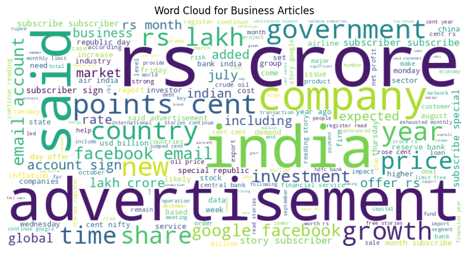

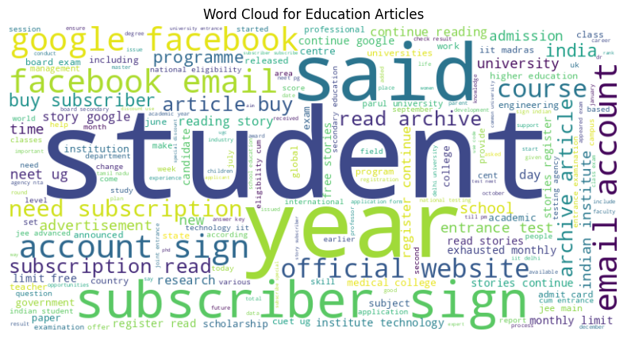

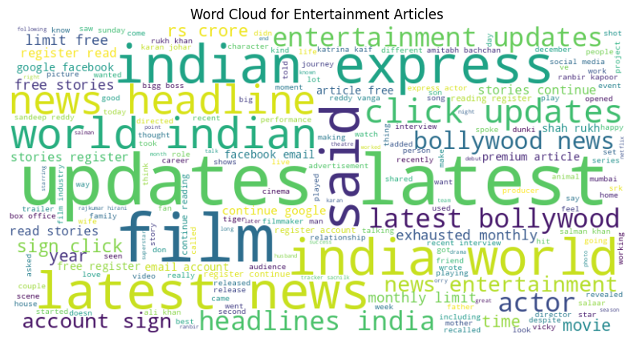

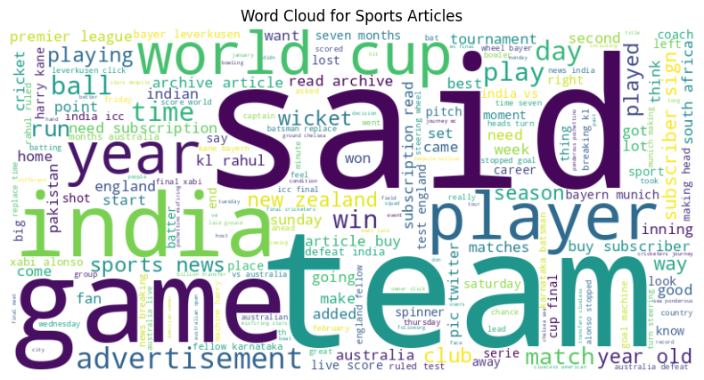

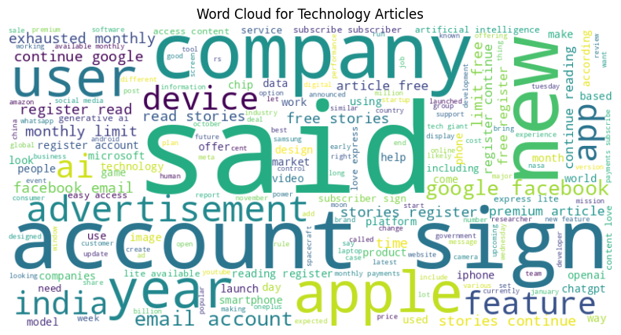

```python
generate_word_clouds(df) # Call the word cloud function
```

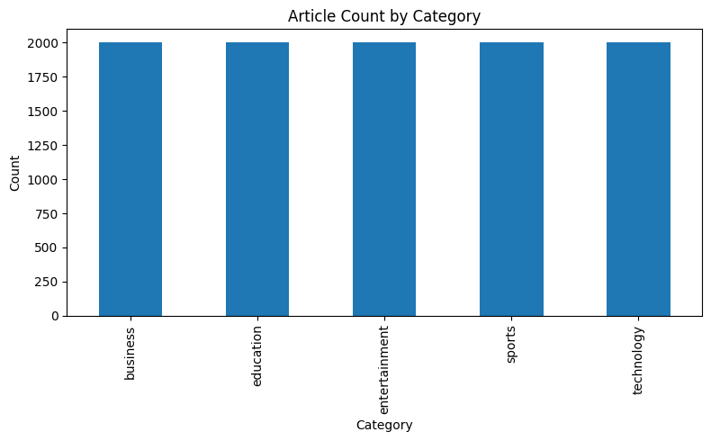

```python
# Adding required plots for Final EDA
plot_category_distribution(df)
```

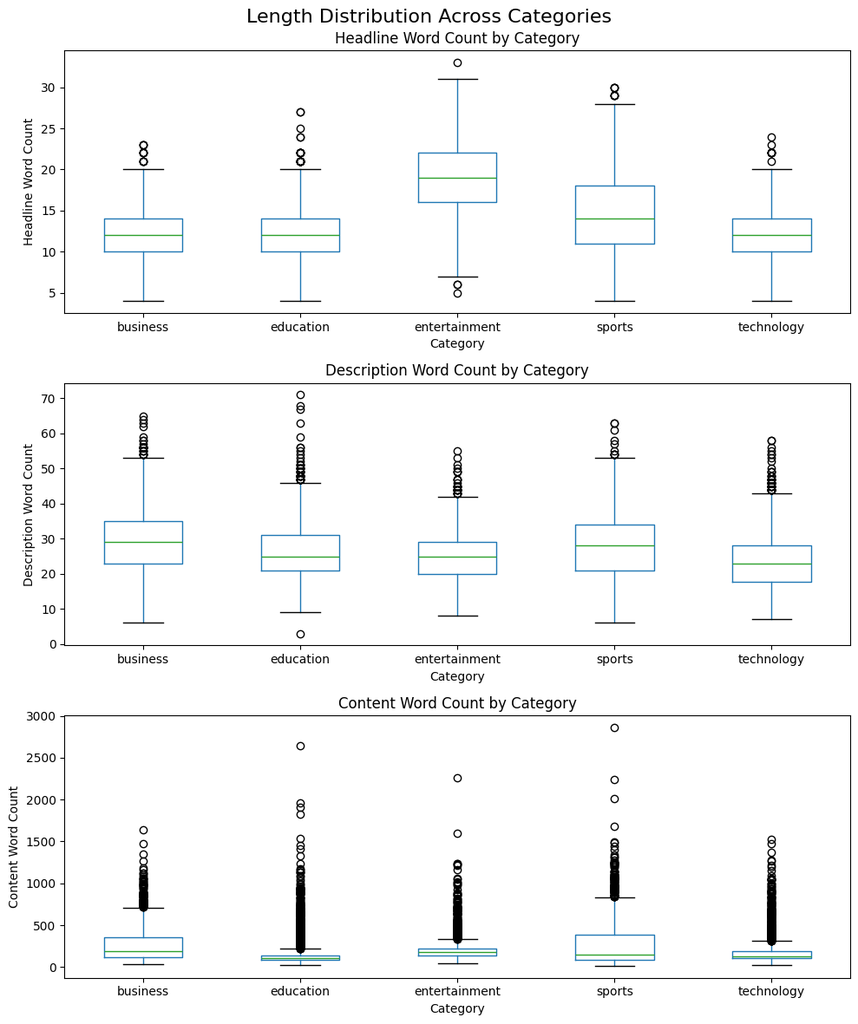

```python
plot_length_distributions(df)
```

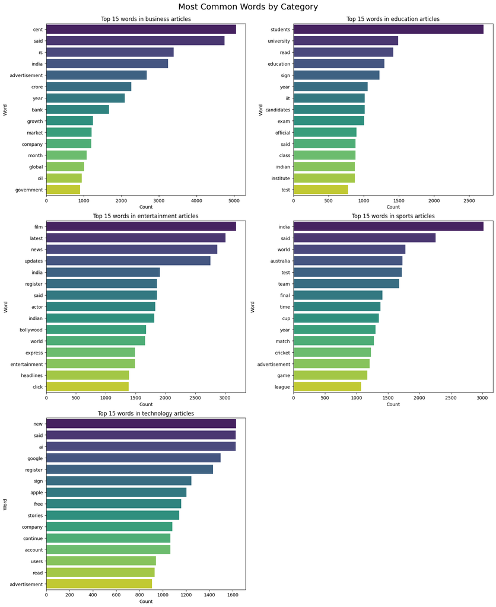

```python
plot_top_words_by_category(df, n=15)
```

```python
# Top words analysis (text table)
all_top_words = {}
for category, subset in df.groupby('category'):
    top_words = top_n_words(subset['content_clean'])
    formatted_words = [f'{word}: {count}' for word, count in top_words]
    all_top_words[category] = formatted_words

top_words_df = pd.DataFrame(all_top_words)

print('\n### Top words in content by Category\n')
print(top_words_df.to_markdown(index=False))

print_section('Milestone 1 Completed')
```

```
### Top words in content by Category

| business            | education        | entertainment       | sports              | technology         |
|:--------------------|:-----------------|:--------------------|:--------------------|:-------------------|
| cent: 5053          | students: 2703   | film: 3186          | india: 3016         | new: 1628          |
| said: 4741          | university: 1492 | latest: 3010        | said: 2256          | said: 1625         |
| rs: 3391            | read: 1421       | news: 2869          | world: 1777         | ai: 1624           |
| india: 3241         | education: 1293  | updates: 2754       | australia: 1730     | google: 1494       |
| advertisement: 2674 | sign: 1223       | india: 1909         | test: 1722          | register: 1431     |
| crore: 2269         | year: 1058       | register: 1860      | team: 1681          | sign: 1245         |
| year: 2094          | iit: 1015        | said: 1859          | final: 1414         | apple: 1201        |
| bank: 1673          | candidates: 1013 | actor: 1829         | time: 1384          | free: 1157         |
| growth: 1240        | exam: 1004       | indian: 1816        | cup: 1354           | stories: 1141      |
| market: 1210        | official: 899    | bollywood: 1676     | year: 1304          | company: 1082      |
| company: 1202       | said: 882        | world: 1661         | match: 1278         | continue: 1065     |
| month: 1076         | class: 882       | express: 1491       | cricket: 1231       | account: 1065      |
| global: 1004        | indian: 875      | entertainment: 1486 | advertisement: 1210 | users: 942         |
| oil: 949            | institute: 873   | headlines: 1391     | game: 1173          | read: 930          |
| government: 906     | test: 774        | click: 1384         | league: 1073        | advertisement: 906 |
| financial: 902      | register: 772    | stories: 1340       | england: 1005       | like: 876          |
| billion: 886        | india: 769       | account: 1277       | second: 929         | monthly: 804       |
| points: 885         | national: 758    | continue: 1275      | play: 907           | year: 728          |
| indian: 854         | exams: 751       | free: 1270          | indian: 907         | facebook: 660      |
| nifty: 854          | subscriber: 724  | sign: 1270          | new: 900            | india: 614         |
| data: 821           | website: 708     | khan: 1167          | ball: 883           | email: 596         |
| day: 819            | medical: 707     | read: 1000          | just: 857           | available: 594     |
| sign: 812           | need: 707        | rs: 927             | sports: 832         | premium: 588       |
| quarter: 786        | board: 680       | films: 790          | day: 831            | limit: 584         |
| prices: 769         | engineering: 655 | shared: 781         | win: 824            | exhausted: 549     |

================================================================================
Milestone 1 Completed
================================================================================
```